# More Resampling Examples: Permutation and Bootstrap

Statistical Computing for Data Analysis

# More permutation examples

So far, permutation has been introduced as a way to approximate a **null distribution** when we do not know or want to assume the data’s distribution under the $H_0$.

Next, we look at settings where the test statistic is more complex than a difference in means.

Examples:

- correlation between two variables
- a difference in medians

### Main idea

The logic is still the same:

1. identify what should be exchangeable under $H_0$
2. permute in a way justified by the null
3. recompute the statistic each time
4. use the resulting values to approximate the null distribution

# Permutation example: correlation

Suppose we want to test whether two variables are associated.

A natural test statistic is the sample correlation

$$T = r(x,y).$$

Under the null hypothesis of **no association**, the observed pairing between $x$ and $y$ should not matter.

So we can:

- keep the $x$ values fixed
- permute the $y$ values
- recompute the sample correlation each time

The resulting distribution is a **permutation distribution** for the correlation under $H_0$.

# Permutation example: correlation in R

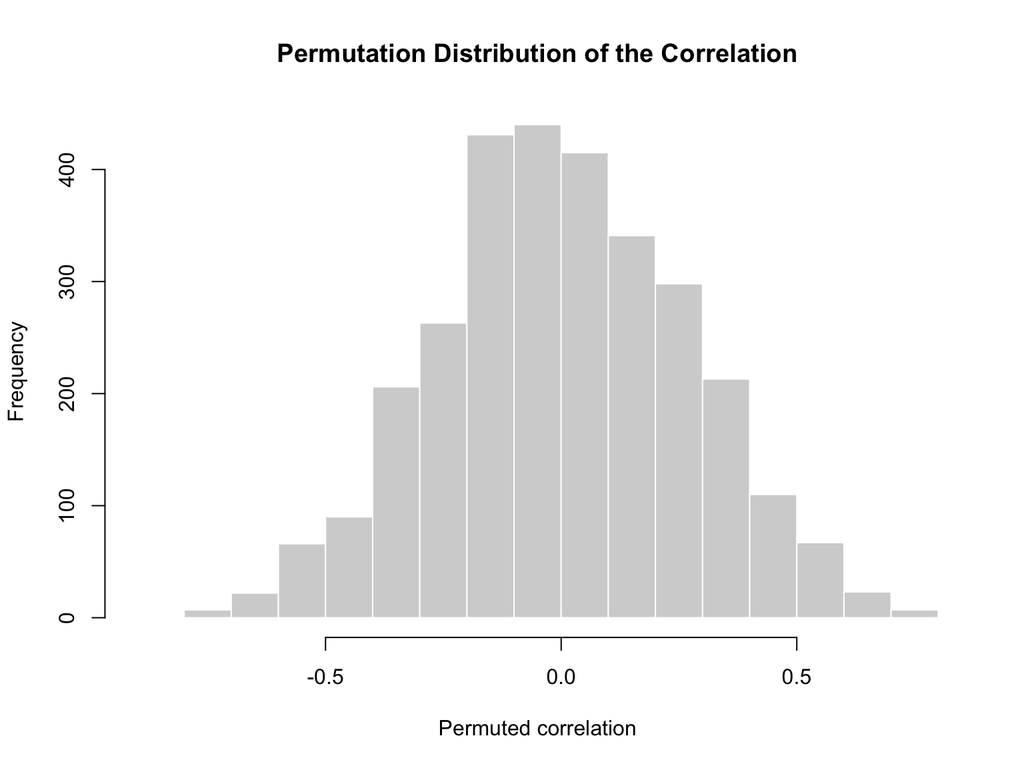

```r
set.seed(123)

x <- c(2.1, 3.4, 4.0, 4.8, 5.2, 6.1, 6.5, 7.3, 8.0, 8.7,
       9.1, 9.8, 10.4, 11.2, 11.8)

y <- c(3.2, 4.1, 4.5, 4.9, 5.7, 6.0, 6.8, 7.4, 7.9, 8.8,
       8.9, 9.5, 10.2, 10.8, 11.6)

T_obs <- cor(x, y)

B <- 3000
T_perm <- numeric(B)

for (b in 1:B) {
  y_labels <- sample(1:length(y))
  y_perm <- y[y_labels]
  T_perm[b] <- cor(x, y_perm)
}

hist(T_perm,
     main = "Permutation Distribution of the Correlation",
     xlab = "Permuted correlation",
     col = "lightgray",
     border = "white")

abline(v = T_obs, lwd = 2, lty = 2)
```

```r
mean(abs(T_perm) >= abs(T_obs))
```

```
## [1] 0
```

# Permutation example: difference in medians

Permutation is also useful when the statistic is not one of the usual textbook choices.

For example, if we want to compare two groups but care about a **difference in medians**, we can use

$$T = \text{median}(X_1) - \text{median}(X_2).$$

Do we know how to derive the null distribution of the median using statistical theory?

If not, we can just use permutation. Under the null hypothesis of no group difference, the labels are exchangeable.

So we can permute the labels exactly as before, but now recompute a **difference in medians** instead of a difference in means.

### Takeaway

Permutation is flexible because it does not require the test statistic to come from a named classical test.

# From null distributions to inference more broadly

So far, we have used simulation and permutation to approximate **null distributions** for hypothesis testing.

But in statistics, we also need distributions for other inferential tasks, such as:

- standard errors
- confidence intervals
- bias estimation

That leads us to another major resampling method: the **bootstrap**.

# Bootstrap: a different inferential goal

Permutation is mainly used to approximate a **null distribution**.

Bootstrap is mainly used to approximate the **sampling distribution of an estimator**.

### Typical bootstrap goals

- estimate a standard error
- construct a confidence interval
- assess bias

### Main idea

Treat the observed sample as a stand-in for the population, then repeatedly sample **with replacement** from the observed data.

# How the bootstrap works

Suppose our statistic of interest is $T$.

The bootstrap procedure is:

1. start with the observed sample
2. draw a bootstrap sample of the same size **with replacement**
3. compute the statistic $T$ on that bootstrap sample
4. repeat many times

The resulting values approximate the **sampling distribution** of the statistic.

# Bootstrap example: sample median

The sample median is often harder to study analytically than the sample mean.

Suppose our statistic is

$$T = \text{median}(X).$$

Suppose we want to estimate its standard error. How could we do that?

We can use the bootstrap to approximate the sampling distribution of the sample median and estimate its standard error.

# Bootstrap example: median in R

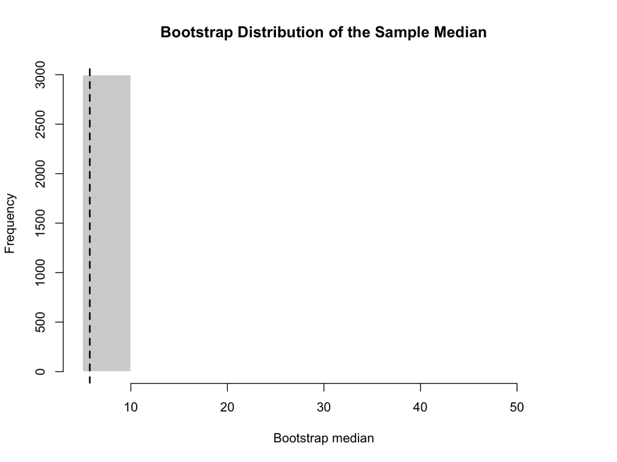

```r
set.seed(123)

x <- c(5.1, 6.2, 4.9, 5.7, 100.0, 6.0, 5.4, 5.8, 6.1, 5.6)

T_obs <- median(x)

B <- 3000
T_boot <- numeric(B)

n <- length(x)

for (b in 1:B) {
  x_boot <- sample(x, size = n, replace = TRUE)
  T_boot[b] <- median(x_boot)
}

hist(T_boot,
     main = "Bootstrap Distribution of the Sample Median",
     xlab = "Bootstrap median",
     col = "lightgray",
     border = "white")

abline(v = T_obs, lwd = 2, lty = 2)
```

```r
sd(T_boot)
```

```
## [1] 1.504813
```

```r
quantile(T_boot, c(0.025, 0.975))
```

```
##  2.5% 97.5%
##   5.4   6.1
```

# Bootstrap example: correlation

We can also bootstrap statistics like the sample correlation.

If our statistic is

$$T = r(x,y),$$

we can:

- resample the observed $(x_i, y_i)$ pairs **with replacement**
- compute the correlation for each bootstrap sample
- use the resulting values to estimate a standard error or confidence interval

### Important note

For bootstrap, we usually resample the **observed units** or **pairs**, not the variables separately.

# Bootstrap example: correlation in R

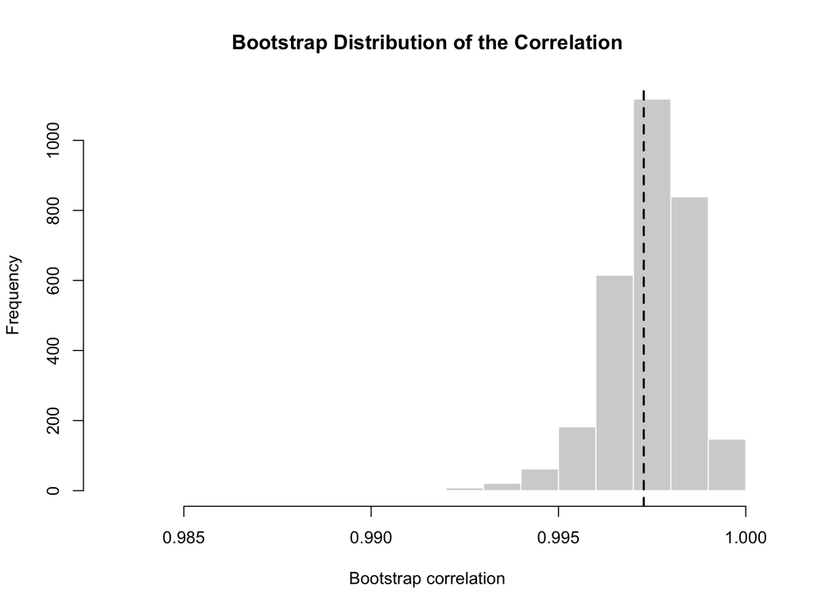

```r
set.seed(123)

x <- c(2.1, 3.4, 4.0, 4.8, 5.2, 6.1, 6.5, 7.3, 8.0, 8.7,
       9.1, 9.8, 10.4, 11.2, 11.8)

y <- c(3.2, 4.1, 4.5, 4.9, 5.7, 6.0, 6.8, 7.4, 7.9, 8.8,
       8.9, 9.5, 10.2, 10.8, 11.6)

dat <- data.frame(x = x, y = y)

T_obs <- cor(dat$x, dat$y)

B <- 3000
T_boot <- numeric(B)
n <- nrow(dat)

for (b in 1:B) {
  idx <- sample(1:n, size = n, replace = TRUE)
  dat_boot <- dat[idx, ]
  T_boot[b] <- cor(dat_boot$x, dat_boot$y)
}

hist(T_boot,
     main = "Bootstrap Distribution of the Correlation",
     xlab = "Bootstrap correlation",
     col = "lightgray",
     border = "white")

abline(v = T_obs, lwd = 2, lty = 2)
```

```r
sd(T_boot)
```

```
## [1] 0.001172787
```

```r
quantile(T_boot, c(0.025, 0.975))
```

```
##      2.5%     97.5%
## 0.9947673 0.9991965
```

# Bootstrap example: regression coefficient

Suppose we fit the model

$$Y_i = \beta_0 + \beta_1 x_i + \varepsilon_i$$

and want uncertainty for $\hat{\beta}_1$.

We can:

- resample the observed $(x_i, y_i)$ pairs **with replacement**
- refit the model on each bootstrap sample
- record the estimated slope each time

This gives a bootstrap approximation to the sampling distribution of $\hat{\beta}_1$.

# Bootstrap example: regression slope in R

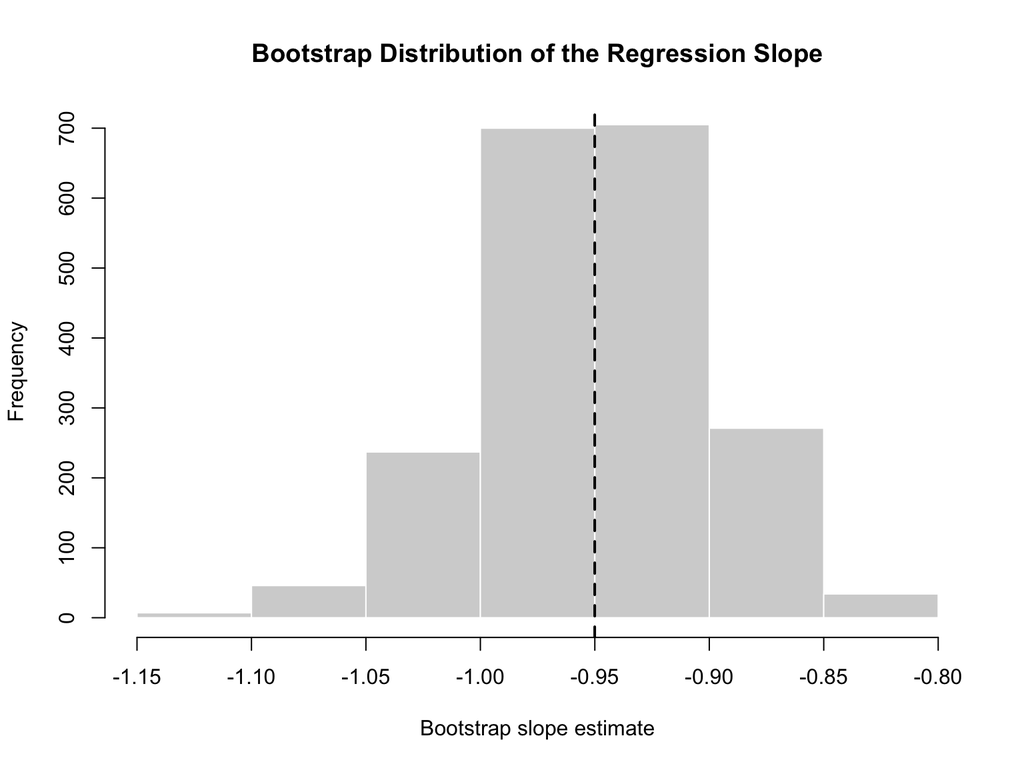

```r
library(ISLR2)
data(Boston)

fit_obs <- lm(medv ~ lstat, data = Boston)
T_obs <- coef(fit_obs)["lstat"]

B <- 2000
T_boot <- numeric(B)
n <- nrow(Boston)

for (b in 1:B) {
  idx <- sample(1:n, size = n, replace = TRUE)
  boot_dat <- Boston[idx, ]
  fit_boot <- lm(medv ~ lstat, data = boot_dat)
  T_boot[b] <- coef(fit_boot)["lstat"]
}

hist(T_boot,
     main = "Bootstrap Distribution of the Regression Slope",
     xlab = "Bootstrap slope estimate",
     col = "lightgray",
     border = "white")

abline(v = T_obs, lwd = 2, lty = 2)
```

```r
sd(T_boot)
```

```
## [1] 0.0494498
```

```r
quantile(T_boot, c(0.025, 0.975))
```

```
##       2.5%      97.5%
## -1.0521315 -0.8568269
```

# Permutation vs bootstrap

Although both involve repeated resampling, they answer different questions.

### Permutation

- target: **null distribution**
- goal: **hypothesis testing**
- common action: shuffle labels, pairings, or assignments

### Bootstrap

- target: **sampling distribution**
- goal: **uncertainty quantification**
- common action: resample observations **with replacement**

# Summary

- **Monte Carlo under $H_0$**: simulate from a known null model
- **Permutation**: build a null distribution from the observed data using exchangeability
- **Bootstrap**: approximate the sampling distribution of an estimator by resampling with replacement

### Big picture

Different resampling methods approximate different distributions used in inference.